# The linear model: Introduction

Rob Davies

Department of Psychology, Lancaster University

## PSYC411: Classes weeks 6-10

- My name is Dr Rob Davies, I am an expert in communication, individual differences, and methods

**Tip**

**Ask me anything**:

- questions during class in person or anonymously through slido;
- all other questions on discussion forum

## Week 8: Focus on the linear model

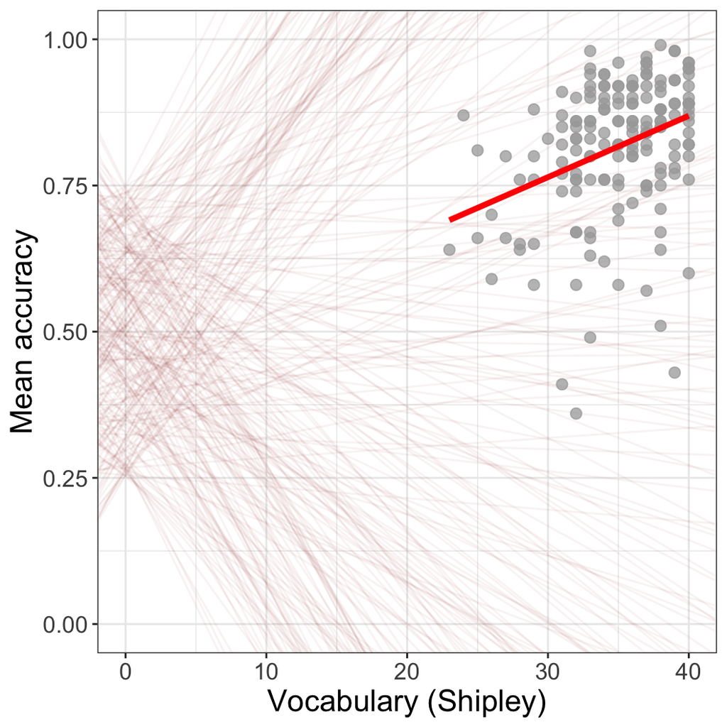

## Analyze + visualize + present

[figure not shown]

Figure 1: The data analysis pipeline or workflow: we focus on the linear model

## The linear model: our aims

1. Understand how to code: `lm(mean.acc ~ SHIPLEY)`
2. To answer questions like: **Is comprehension success influenced by vocabulary knowledge?**

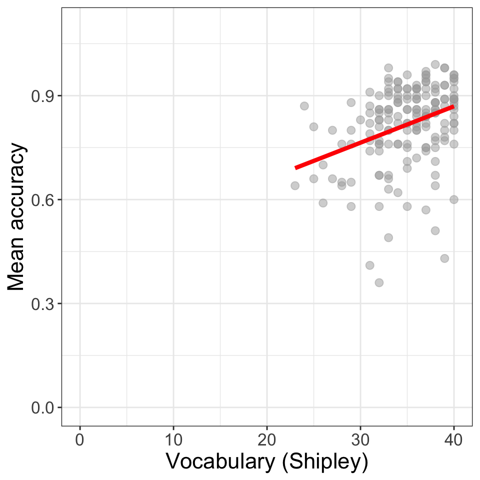

Figure 2: Scatterplot showing the potential association between accuracy of comprehension and vocabulary scores

## Using the linear model to answer research questions

- We will learn how to:
1. code linear models
2. identify and interpret model statistics
3. critically evaluate the results
4. communicate the results

## Thinking about relationships in psychologial science

We often want to know about relationships

- Does variation in X predict variation in Y?
- What are the factors that influence outcome Y?
- Is a theoretical model consistent with observed behaviour?

## Now consider our research aims in the *context* of the health comprehension project

1. Because public health impacts depend on giving people information they can understand
2. We want to know: **What makes it easy or difficult to understand written health information?**

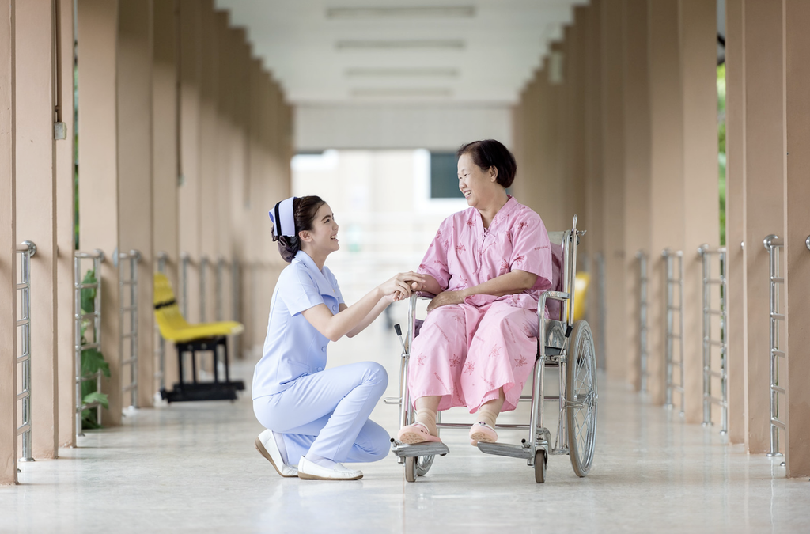

flickr: Sasin Tipchair ‘Senior woman in wheelchair talking to a nurse in a hospital’

## Health comprehension project: questions and analyses

1. We want to know: **What makes it easy or difficult to understand written health information?**
2. So our research questions are:
- What person attributes predict success in understanding?
- Can people accurately evaluate whether they correctly understand written health information?
3. These kinds of research questions can be answered using methods like linear models

## Context: Individual differences theory of comprehension success

- Understanding text depends on (1.) language experience and (2.) reasoning ability (Freed et al., 2017)

## The measurement context: Where the data come from

- We measure reading comprehension: asking people to read text and then answer multiple choice questions
- We measure background knowledge: vocabulary knowledge (Shipley); health literacy (HLVA)

## Reflect: The kinds of critical evaluation questions you can ask yourself

- Are multiple choice questions good ways to probe understanding? *What alternatives are there?*
- Are tests like the Shipley good measures of language knowledge? *What do we miss?*

## Reflect: As we move into thinking about the data analysis, we need to identify our assumptions

1. **validity**: that differences in knowledge or ability cause differences in test scores
2. **measurement**: that this is equally true across the different kinds of people we tested
3. **generalizability**: that the sample of people we recruited looks like the population

## We need to think about the derivation chain

[figure not shown]

Figure 4: The derivation chain

## Questions, assumptions, predictions

Link: concepts, questions $\rightarrow$ assumptions $\rightarrow$ testable predictions

1. **concepts, questions**: Can people accurately understand health guidance? $\rightarrow$
2. **assumptions**: People who know more about language should also present more accurate understanding $\rightarrow$
3. **testable predictions**: Higher levels of vocabulary should be associated with higher levels of comprehension accuracy: we expect to estimate a positive coefficient

## One way of thinking about the association is to visualize it

- For each value of the predictor **vocabulary**
- Does the the value of the outcome **accuracy**
- *Increase or decrease?*

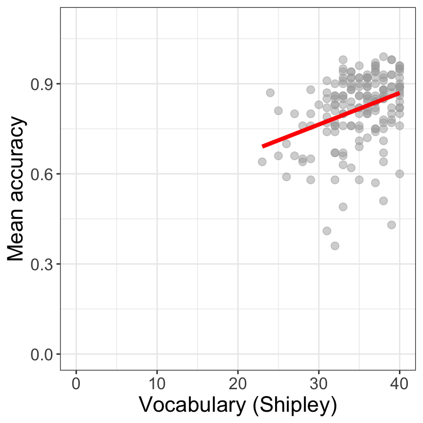

Figure 5: The association between comprehension accuracy and vocabulary

## Let’s take a break

- End of part 1

## Predicted association as *expected* change in average outcome

- Figure 6 shows the distribution curve of mean (comprehension) accuracy scores observed at each value of vocabulary
- You can see that the middle – the average – of each distribution increases
- as we go from left (low scores) to right (high scores) on vocabulary

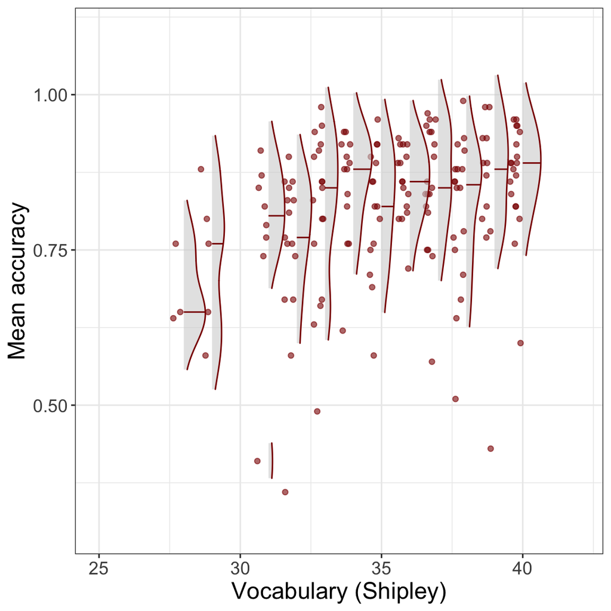

Figure 6: Association between accuracy and vocabulary

## How do we *estimate* the association between two variables?

```r
model <- lm(mean.acc ~ SHIPLEY,
            data = clearly.one.subjects)
summary(model)
```

1. Specify the `lm` function and the model `mean.acc ~ SHIPLEY`
2. Specify what data we use `data = clearly.one.subjects`
3. Get the results `summary(model)`

## The sentence structure of models in R

Take a good look:

```r
lm(mean.acc ~ SHIPLEY ...)
```

You will see this sentence structure in coding for *many* different analysis types

- `method(outcome ~ predictors)`
- `method` could be `aov, brm, lm, glm, glmm, lmer, t.test, cor.test`

## Results: How does the outcome vary in relation to the predictor?

```
Call:
lm(formula = mean.acc ~ SHIPLEY, data = clearly.one.subjects)

Residuals:
     Min       1Q   Median       3Q      Max
-0.42871 -0.04921  0.02079  0.07480  0.18430

Coefficients:
            Estimate Std. Error t value Pr(>|t|)
(Intercept)  0.44914    0.08053   5.577 9.67e-08 ***
SHIPLEY      0.01050    0.00229   4.585 8.85e-06 ***
---
Signif. codes:  0 '***' 0.001 '**' 0.01 '*' 0.05 '.' 0.1 ' ' 1

Residual standard error: 0.1115 on 167 degrees of freedom
Multiple R-squared:  0.1118,    Adjusted R-squared:  0.1065
F-statistic: 21.03 on 1 and 167 DF,  p-value: 8.846e-06
```

- A model summary gives us estimates of:
- The coefficient $= 0.44914$ for the intercept
- The coefficient $= 0.01050$ for the slope of the SHIPLEY ‘effect’

## These *coefficients* build a line

- The line represents:
- our prediction for how the outcome varies *on average*
- given change in the predictor

## So now we need to think about straight lines

$$y = a + bx$$

2. We calculate the height $y$ by adding
- $a$ the intercept, the value of y when $x = 0$
- to the product of $b$ the coefficient for the slope of the line
- multiplied by $x$ the value of the predictor variable

## Let’s draw it

- Look at what we get if we draw the line using the linear model coefficients:
- $= 0.449$ for the intercept, $a$
- $= 0.011$ for the slope, $b$
- In the formula: $y = 0.449 + 0.011x$
- (I round the numbers to three decimal places.)

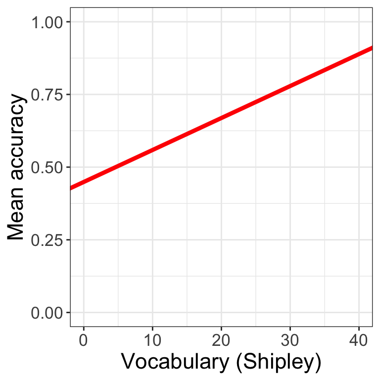

Figure 7: The *predicted* association between comprehension accuracy and vocabulary

## We can understand the line as representing a set of predictions

- To see how — we use the coefficients to predict just one potential outcome:
- the expected accuracy for someone with a vocabulary score of 20
- We do this using the formula:

$\text{predicted y} = 0.449 + \text{0.011 } \times \text{ Shipley score of } 20$

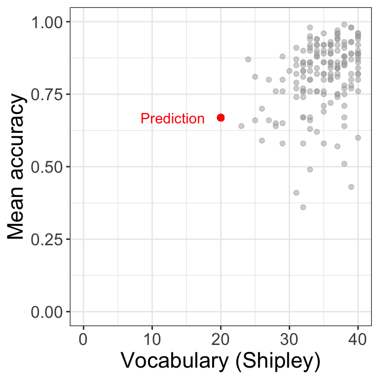

Figure 8: Predicted outcome in red

## We can understand the line as representing a set of predictions

- Let’s expand our predictions
1. Predict accuracy given a Shipley score of 20
- $y = 0.449 + 0.011 \times 20$
2. Predict accuracy given a Shipley score of 30
- $y = 0.449 + 0.011 \times 30$

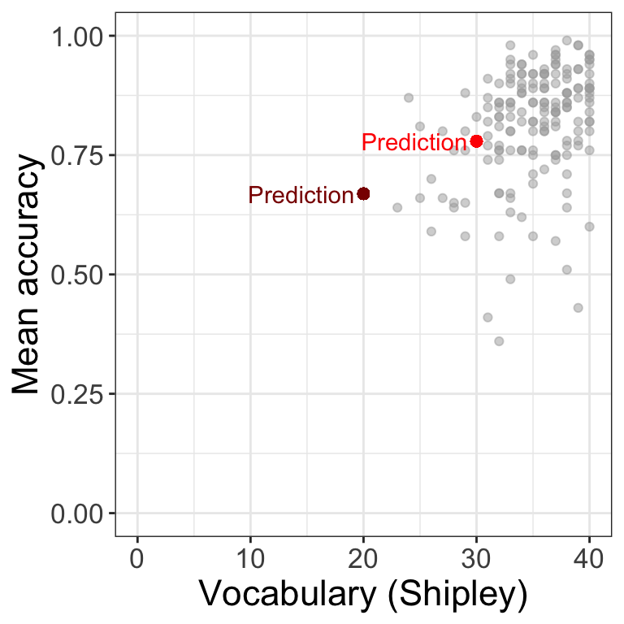

Figure 9: Predicted outcome in red

## The linear model allows us to predict the average outcome we can expect given *any* value of the predictor

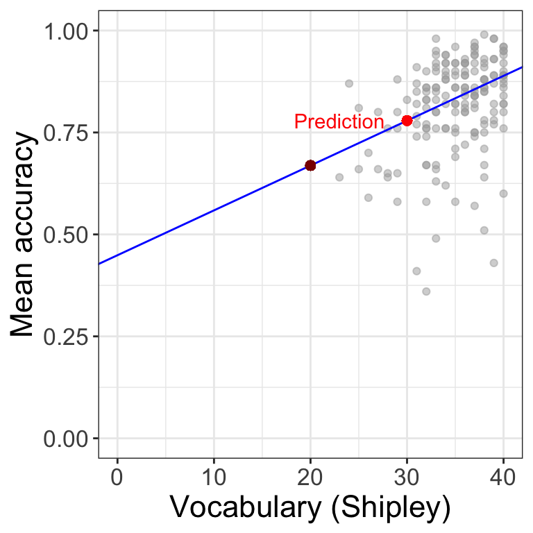

Figure 10: The predicted change in mean comprehension accuracy, given variation in vocabulary scores

## Let’s take a break

- End of part 2

## We could draw a variety of different model prediction lines: how do we pick the *right* one?

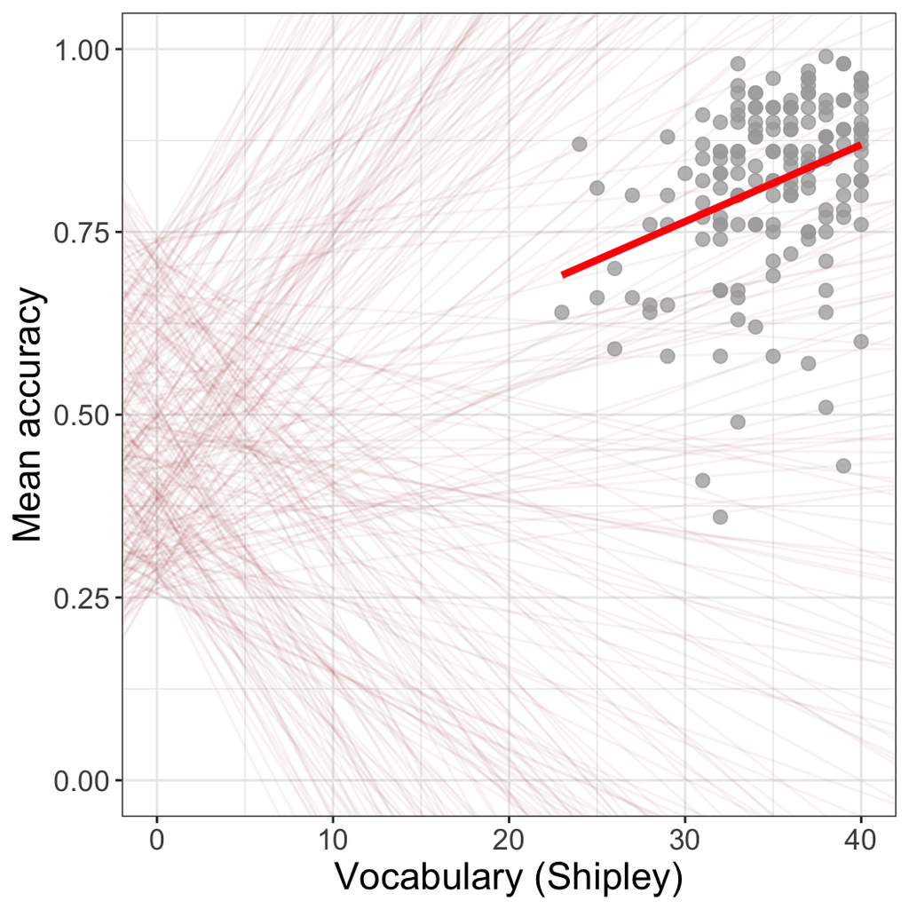

## We could draw a variety of different model prediction lines: how do we pick the *right* one?

We need to go back to the prediction model

- To calculate a predicted outcome value, we calculated it as: $\text{predicted y} = 0.449 + 0.011 \times \text{ Shipley score } 20$
- Assuming the linear model $\text{predicted y} = intercept + \text{slope } \times \text{ vocabulary}$
- But we missed a bit: **error**

## Linear models are typically estimated given sample data

- Maybe you noticed that I talked about how the model allows us to predict
- how the outcome varies **on average** given different values of the predictor
- When we use a linear model to estimate the intercept and slope – to build the predictions – we fit a model to the sample data
- And no model will fit sample data perfectly

## Linear models are typically estimated given sample data

Usually, this means there are differences between the expected outcomes that the model predicts and the observed outcomes

- So we often write the linear model like this: $y = a + bx + \epsilon$
1. The observed outcome $y$ equals
2. the intercept $a$
3. plus the difference associated with a specific predictor value $bx$
4. plus some amount of mismatch or error $\epsilon$, the difference between the observed outcome and the predicted outcome

## We can derive the formulas used to calculate the estimates using calculus

- But we won’t
- Because the linear model calculations are done using matrix solution algorithms in R *so we don’t have to*

## What the prediction errors look like

- If the regression model were perfect then all the observed points would lie on the prediction line
- They do not

## We typically assume that the residuals are normally distributed

- Some are positive: observed outcome larger than predicted outcome
- Some are negative: observed outcome smaller than predicted outcome
- The average of the residuals will be zero overall

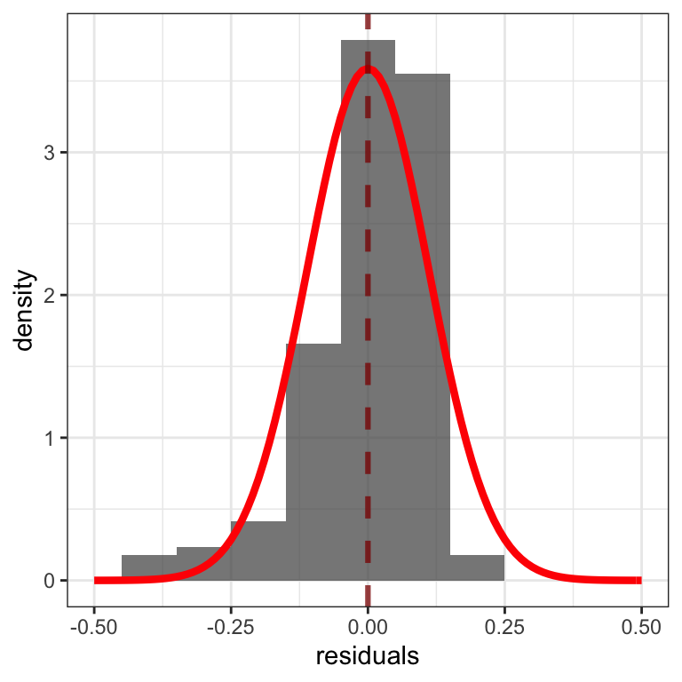

Figure 15: Plot showing the distribution of prediction errors – residuals – for the linear model of comprehension accuracy

## So: We pick the line that minimizes the residuals – the mismatch between predicted and observed outcomes

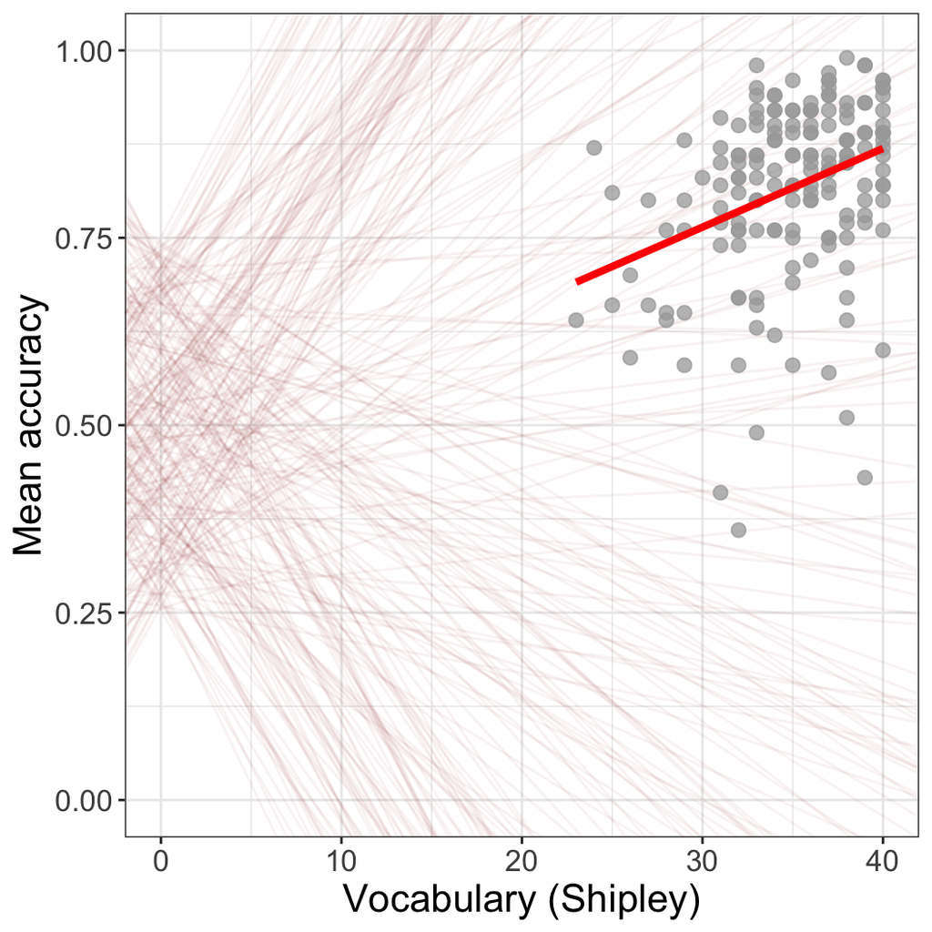

## Let’s take a break

- End of part 3

## Identifying the key information in the linear model results

- The `summary()` of the linear model shows …
- The `Estimate` of the `Coefficient` of the effect of individual differences in vocabulary (`SHIPLEY`)
- how much the outcome `mean.acc` value changes, given differences in `SHIPLEY` score
- Associated `t value` and `Pr(> |t|)` statistics for the coefficient t-test
- Model fit statistics: `R-squared` and `F-statistic`

```
Call:
lm(formula = mean.acc ~ SHIPLEY, data = clearly.one.subjects)

Residuals:
     Min       1Q   Median       3Q      Max
-0.42871 -0.04921  0.02079  0.07480  0.18430

Coefficients:
            Estimate Std. Error t value Pr(>|t|)
(Intercept)  0.44914    0.08053   5.577 9.67e-08 ***
SHIPLEY      0.01050    0.00229   4.585 8.85e-06 ***
---
Signif. codes:  0 '***' 0.001 '**' 0.01 '*' 0.05 '.' 0.1 ' ' 1

Residual standard error: 0.1115 on 167 degrees of freedom
Multiple R-squared:  0.1118,    Adjusted R-squared:  0.1065
F-statistic: 21.03 on 1 and 167 DF,  p-value: 8.846e-06
```

## For the effect of vocabulary (SHIPLEY), we have:

- The coefficient for the slope of the effect of variation in vocabulary scores: `0.01050`
- The `Std. Error` (standard error) `0.00229` for that estimate
- The `t`value `4.585` and associated `Pr(>|t|)` p-value `8.85e-06` for the null hypothesis test of the coefficient

```
Call:
lm(formula = mean.acc ~ SHIPLEY, data = clearly.one.subjects)

Residuals:
     Min       1Q   Median       3Q      Max
-0.42871 -0.04921  0.02079  0.07480  0.18430

Coefficients:
            Estimate Std. Error t value Pr(>|t|)
(Intercept)  0.44914    0.08053   5.577 9.67e-08 ***
SHIPLEY      0.01050    0.00229   4.585 8.85e-06 ***
---
Signif. codes:  0 '***' 0.001 '**' 0.01 '*' 0.05 '.' 0.1 ' ' 1

Residual standard error: 0.1115 on 167 degrees of freedom
Multiple R-squared:  0.1118,    Adjusted R-squared:  0.1065
F-statistic: 21.03 on 1 and 167 DF,  p-value: 8.846e-06
```

## Identifying the key information in the results

- Pay attention to the **sign and the size** of the coefficient estimate:
- Is the coefficient (e.g., SHIPLEY `0.01050`) a positive or a negative number?
- Is it relatively large or small?
- We come back to this, shortly, in the context of interpretation and reporting

```
Call:
lm(formula = mean.acc ~ SHIPLEY, data = clearly.one.subjects)

Residuals:
     Min       1Q   Median       3Q      Max
-0.42871 -0.04921  0.02079  0.07480  0.18430

Coefficients:
            Estimate Std. Error t value Pr(>|t|)
(Intercept)  0.44914    0.08053   5.577 9.67e-08 ***
SHIPLEY      0.01050    0.00229   4.585 8.85e-06 ***
---
Signif. codes:  0 '***' 0.001 '**' 0.01 '*' 0.05 '.' 0.1 ' ' 1

Residual standard error: 0.1115 on 167 degrees of freedom
Multiple R-squared:  0.1118,    Adjusted R-squared:  0.1065
F-statistic: 21.03 on 1 and 167 DF,  p-value: 8.846e-06
```

## The t-tests in the linear model

$$t = \frac{\beta_j}{s_{\beta_j}}$$

- For each coefficient, the t-test is used to evaluate if the coefficient $\beta_j$ is significantly different from zero
- We assume the **null hypothesis** that the coefficient $\beta_j$ is zero
- We do the test by comparing the estimated coefficient $\beta_j$ with the standard error of the estimate

## The t-tests in the linear model

$$t = \frac{\beta_j}{s_{\beta_j}}$$

- The standard error $s_{\beta_j}$ indicates our **uncertainty** about the estimate
- Larger standard errors represent greater uncertainty

## The t-tests in the linear model

$$t = \frac{\beta_j}{s_{\beta_j}}$$

- Standard errors can be calculated using information about:
- Error in the model — think of the distribution of residuals
- Variation of values in the predictor — how widely they range
- The sample size
- Standard errors will be smaller for the coefficients of effects that appear to have bigger impacts, in models that describe outcomes better, in larger samples

## Identifying the key information in the results

- Pay attention to R-squared:
- The model summary gives us the `Multiple R-squared` and `Adjusted R-squared`
- These numbers represent how much of the variation in the outcome can be predicted by the model
- We usually report `Adjusted R-squared` because it tends to be more accurate

```
Call:
lm(formula = mean.acc ~ SHIPLEY, data = clearly.one.subjects)

Residuals:
     Min       1Q   Median       3Q      Max
-0.42871 -0.04921  0.02079  0.07480  0.18430

Coefficients:
            Estimate Std. Error t value Pr(>|t|)
(Intercept)  0.44914    0.08053   5.577 9.67e-08 ***
SHIPLEY      0.01050    0.00229   4.585 8.85e-06 ***
---
Signif. codes:  0 '***' 0.001 '**' 0.01 '*' 0.05 '.' 0.1 ' ' 1

Residual standard error: 0.1115 on 167 degrees of freedom
Multiple R-squared:  0.1118,    Adjusted R-squared:  0.1065
F-statistic: 21.03 on 1 and 167 DF,  p-value: 8.846e-06
```

## R-squared – what is it? – an indicator of the proportion of outcome variation we can predict

- Better models should show smaller differences between observed and predicted outcomes
- R-squared ($R^2$) gives the proportion of outcome variance
- we can predict given information about differences in vocabulary

## R-squared as an indicator of the proportion of the outcome variation we can predict

- To understand what this means, look at the scatterplot
- On average, values in outcome (accuracy) increase with increasing values in the predictor (vocabulary)
- But different people got different outcomes even with same vocabulary scores

## R-squared as an indicator of the proportion of the outcome variation we can predict

- So: we have variation in the outcome that is related to variation in the predictor
- And: we have variation in the outcome that seems unrelated to the predictor
- $R^2$ tells us how much variation in the outcome is explained by the model
- $R^2$ gives us a proportion where $R^2 = \frac{\text{predicted outcome variation}}{\text{total outcome variation}}$

## Identifying the key information in the results

- Pay attention to F:
- The model summary gives us the F-statistic:
- This is the test statistic for the test of the null hypothesis that the model does not predict the outcome

```
Call:
lm(formula = mean.acc ~ SHIPLEY, data = clearly.one.subjects)

Residuals:
     Min       1Q   Median       3Q      Max
-0.42871 -0.04921  0.02079  0.07480  0.18430

Coefficients:
            Estimate Std. Error t value Pr(>|t|)
(Intercept)  0.44914    0.08053   5.577 9.67e-08 ***
SHIPLEY      0.01050    0.00229   4.585 8.85e-06 ***
---
Signif. codes:  0 '***' 0.001 '**' 0.01 '*' 0.05 '.' 0.1 ' ' 1

Residual standard error: 0.1115 on 167 degrees of freedom
Multiple R-squared:  0.1118,    Adjusted R-squared:  0.1065
F-statistic: 21.03 on 1 and 167 DF,  p-value: 8.846e-06
```

## Reporting the results of a linear model

- You will need to report three bits of information:
1. $R^2$ how much outcome variation is explained by the model
2. $F$ test for the null hypothesis that none of the predictors actually predict the outcome
3. Coefficient estimates with the t-tests for the null hypothesis for each coefficient

```
Call:
lm(formula = mean.acc ~ SHIPLEY, data = clearly.one.subjects)

Residuals:
     Min       1Q   Median       3Q      Max
-0.42871 -0.04921  0.02079  0.07480  0.18430

Coefficients:
            Estimate Std. Error t value Pr(>|t|)
(Intercept)  0.44914    0.08053   5.577 9.67e-08 ***
SHIPLEY      0.01050    0.00229   4.585 8.85e-06 ***
---
Signif. codes:  0 '***' 0.001 '**' 0.01 '*' 0.05 '.' 0.1 ' ' 1

Residual standard error: 0.1115 on 167 degrees of freedom
Multiple R-squared:  0.1118,    Adjusted R-squared:  0.1065
F-statistic: 21.03 on 1 and 167 DF,  p-value: 8.846e-06
```

## The language and style of reporting linear model results

Here is an example of results reporting text that is conventional:

> We fitted a linear model with mean comprehension accuracy as the outcome and vocabulary (Shipley) as the predictor. Our analysis indicated a significant effect of vocabulary knowledge. The model is significant overall, with $F(1, 167) = 21.03, p < .001$, and explains 11% of variance ($\text{adjusted } R^2 = 0.11$). The model estimates showed that the accuracy of comprehension increased with increasing levels of participant vocabulary knowledge ($\beta = .011, t = 4.59, p <.001$).

## Look at what we do with the text

> We fitted a linear model with mean comprehension accuracy as the outcome and vocabulary (Shipley) as the predictor. Our analysis indicated a significant effect of vocabulary knowledge. The model is significant overall, with $F(1, 167) = 21.03, p < .001$, and explains 11% of variance ($\text{adjusted } R^2 = 0.11$). The model estimates showed that the accuracy of comprehension increased with increasing levels of participant vocabulary knowledge ($\beta = .011, t = 4.59, p <.001$).

## Summary

- In psychological science, we often ask questions like:
1. Does variation in X predict variation in Y?
2. What are the factors that influence outcome Y?
3. Is a theoretical model consistent with observed behaviour?
- We can answer these questions using the linear model
- Given sample data, we can predict the average difference in outcome values, for different levels of a predictor variable
- We (or the math engine R uses) calculate the predictions so that they minimize the residuals, the errors of prediction or the mismatch between predicted and observed outcomes
- Our results report tells the reader about the model and the estimated effects

## References

Freed, E. M., Hamilton, S. T., & Long, D. L. (2017). Comprehension in proficient readers: The nature of individual variation. *Journal of Memory and Language*, *97*, 135–153. https://doi.org/10.1016/j.jml.2017.07.008